# GLM: Model-Specific Assumptions

Rebecca Gill

2026-05-15

NOTE: This page is built in R Markdown. Most code chunks are hidden by default. To see all the R code, click “Code” at the top of the page and select “Show All Code”. To see the code used to generate a specific output, you can click the “Show” button above the output to see the code that generated that output. The full R Markdown code is also available in my [studycourts/gradData GitHub repository](https://github.com/studycourts/gradData/tree/main/pages).

```r
P <- c(
  "knitr",          # rendering
  "kableExtra",     # table formatting
  "texreg",         # htmlreg() for model tables
  "modelsummary",   # more pretty tables
  "ordinal",        # clm(), clmm(), nominal_test()
  "MASS",           # polr() — needed by brant and vif
  "brant",          # brant() test for PO assumption
  "gofcat",         # brant.test() and gof() for ordinal models
  "VGAM",           # vglm() for GOL, PPO, SLM, multinomial
  "clustord",       # for osm(), a nice way to do SLM
  "mlogit",         # for multinomial logit
  "nnet",           # multinom() for standard multinomial logit
  "lmtest",         # lrtest()
  "ggeffects",      # ggpredict() for effect plots
  "patchwork",      # combining ggplots
  "tidyverse"       # wrangling and ggplot2 — load last
)

for (pkg in P) {
  if (!require(pkg, character.only = TRUE)) {
    install.packages(pkg, repos = "http://cran.us.r-project.org")
  }
  library(pkg, character.only = TRUE)
}

rm(P, pkg)  # clean up the mess
```

```r
set.seed(1975)

# sim 1: 3-cat ordinal y; 2 continuous x; PO holds for all x

n.po   <- 800                          # obs
x1.po  <- rnorm(n.po)                  # x1
x2.po  <- rnorm(n.po)                  # x2
lat.po <- -0.9 * x1.po + 0.5 * x2.po + rlogis(n.po)
y.po   <- cut(lat.po,
              breaks = c(-Inf, -0.8, 0.8, Inf),
              labels = c("low", "medium", "high"))
y.po   <- factor(y.po, ordered = TRUE) # ordinal y

po.df  <- data.frame(y = y.po, x1 = x1.po, x2 = x2.po)

# sim 2: 3-cat ordinal y; 2 continuous x; PO violated for x1
n.vio  <- 800                         # obs
x1.vio <- rnorm(n.vio)                # x1
x2.vio <- rnorm(n.vio)                # x2
b1.t1  <- -0.8                        # x1 at threshold 1
b1.t2  <- -0.2                        # x1 at threshold 2 (violation)
b2     <-  0.5                        # x2 same at both (PO holds)
eta1   <- -1.0 + b1.t1 * x1.vio + b2 * x2.vio   # cumulative log-odds, cut 1
eta2   <-  1.0 + b1.t2 * x1.vio + b2 * x2.vio   # cumulative log-odds, cut 2
p1     <- plogis(eta1)
p2     <- plogis(eta2)
u      <- runif(n.vio)
y.vio  <- factor(
  case_when(u < p1 ~ "low", u < p2 ~ "medium", TRUE ~ "high"),
  levels  = c("low", "medium", "high"),
  ordered = TRUE
)                                      # ordinal y

vio.df <- data.frame(y = y.vio, x1 = x1.vio, x2 = x2.vio)

# sim 3: 4-cat nominal y; continuous x1 binary x2
n.mn <- 1000                          # obs
lr   <- rnorm(n.mn)                   # left-right ideology
ru   <- rbinom(n.mn, 1, 0.45)         # rural (1) vs. urban (0)

# true log-odds relative to baseline (party A):
# party B: left-leaning urban party
# party C: right-leaning party (both contexts)
# party D: rural populist party
xb.b <- -0.3 - 1.2 * lr + 0.8 * ru  # B vs. A
xb.c <-  0.2 + 1.1 * lr - 0.3 * ru  # C vs. A
xb.d <- -0.5 - 0.4 * lr + 1.5 * ru  # D vs. A

# convert to probabilities
denom <- 1 + exp(xb.b) + exp(xb.c) + exp(xb.d)
p.a   <- 1           / denom
p.b   <- exp(xb.b)   / denom
p.c   <- exp(xb.c)   / denom
p.d   <- exp(xb.d)   / denom

# simulate the choice
party <- apply(cbind(p.a, p.b, p.c, p.d), 1,
               function(p) sample(c("A","B","C","D"), 1, prob = p))
party <- factor(party)

mn.df <- data.frame(party = party, lr = lr, ru = ru)
```

## Introduction

Every model in the GLM family carries the general assumptions we’ve discussed on other pages in this series (e.g., correct distributional family, linearity on the link scale, no influential outliers). But some model families also carry assumptions that are specific to their particular structure: assumptions that don’t arise in binary logistic regression or Poisson models, but that become important the moment you extend to ordinal or nominal outcomes.

This page covers two such assumptions:

- The **proportional odds assumption** is specific to ordered logit and ordered probit models. It also happens to be one of the more commonly violated (and ignored) assumptions in the political science literature (Long and Freese 2014).
- The **independence of irrelevant alternatives** (IIA) assumption is specific to the multinomial logit model, and it’s one of the most commonly misunderstood (Patty and Penn 2019).

Both are worth understanding because they have clear implications for how to specify your model and how to interpret its results. It’s also good to be aware that there is a lot of debate in the literature about whether/when/how these assumptions matter, since you may come across reviewers who have contrary opinions on the subject.

## The PO Assumption

### What It Is

The proportional odds (PO) model — the standard ordered logit — estimates a single coefficient $\hat{\beta}_j$ for each predictor $x_j$, and it constrains that coefficient to be the same at every threshold of the ordinal outcome. If your outcome has three categories (low, medium, high), the model estimates two cumulative log-odds equations:

$$\log\frac{P(Y \leq \text{low})}{P(Y > \text{low})} = \alpha_1 - \boldsymbol{\beta}^\top \mathbf{x}$$

$$\log\frac{P(Y \leq \text{medium})}{P(Y > \text{medium})} = \alpha_2 - \boldsymbol{\beta}^\top \mathbf{x}$$

Notice that $\boldsymbol{\beta}$ is the same in both equations. The thresholds ($\alpha_1$ and $\alpha_2$) shift, but the effect of the predictors stays constant across the threshold. This is the proportional odds assumption: the log-odds of being at or below any given category are proportional across values of the predictors, with the proportionality constant being $e^{\beta_j}$.

Does this mean that the $\hat{\beta}$ on a variable stays the same across all of the $j$ categories of $Y$?

Exactly. This is analogous to how linear regression works. How we interpret an OLS coefficient is something like this:

> Each one unit increase in $X$ is associated with a $\beta$-unit change in $Y$, all else equal.

The PO assumption basically means that the effect of $X$ on $Y$ is the same when comparing category $j$ with category $j + 1$ as it is comparing category $j + 1$ to category $j+2$, etc. Visually, this means that if you fit a separate binary logit for each cumulative threshold (low vs. not-low, medium-or-low vs. high), the coefficient estimates for each predictor should be approximately the same across those binary models. The PO model is essentially fitting all of those binary logits simultaneously, under the constraint that the coefficients are equal.

I see. But why does this constraint exist? Couldn’t we just let the coefficients be different at each threshold?

We could. When the PO assumption fails, that’s exactly what we do (more on this below). The constraint exists because it makes the model parsimonious: instead of estimating $(J-1) \times k$ coefficients (where $J$ is the number of outcome categories and $k$ is the number of predictors), we estimate only $k$ coefficients plus $(J-1)$ thresholds. With many categories and predictors, that’s a substantial saving. And when the constraint is appropriate (i.e., when the predictors really do have the same association with the outcome across all thresholds) the PO model is more efficient than its unconstrained alternatives.

The problem is that the assumption is often wrong in practice. For example, the effect of more education when comparing the probability of *strong* versus *mild support* for a policy might be much larger than the effect of more education when comparing *mild* versus *no support*. Similarly, the effect of ideology on voting for a far-right party might be nonlinear across the scale. When the assumption fails and we ignore it, the PO model gives us a coefficient that is a kind of weighted average across the thresholds — interpretable in a rough sense, but potentially misleading about where in the outcome distribution the action is really happening.

That sounds bad. How do we know if we’ve violated this?

It is bad, in that it can conceal what’s really going on. But we’ve got a few tools to help us determine whether our PO model violates this assumption.

### Visualizing the Assumption

Before running formal tests, it’s worth seeing what the PO assumption looks like. To do this, we’ll start by estimating a PO model. Then, we’ll re-estimate the model, letting the coefficients vary (this is a generalized ordered logit or GOL; more on that later). Under the PO assumption, the points for each variable should be close to each other and to the PO model’s estimate.

Figure 1: Estimates from PO model (dotted line) vs. GOL (points).

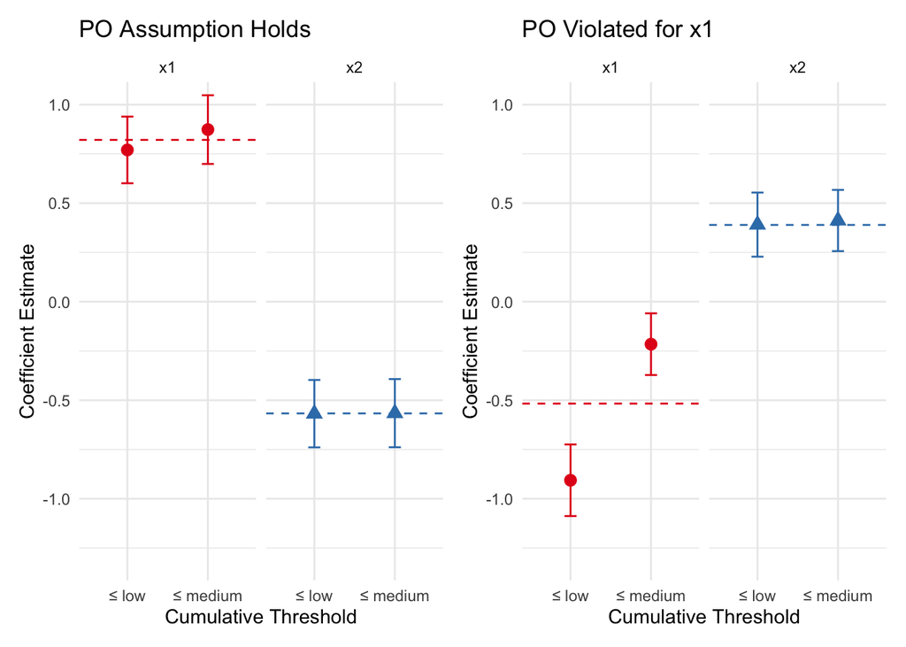

```r
# estimate models using VGAM
po.vglm  <- VGAM::vglm(y ~ x1 + x2,
                        family = VGAM::cumulative(
                          parallel = TRUE, reverse = FALSE),
                        data = po.df)
vio.vglm <- VGAM::vglm(y ~ x1 + x2,
                        family = VGAM::cumulative(
                          parallel = TRUE, reverse = FALSE),
                        data = vio.df)

gol.po  <- VGAM::vglm(y ~ x1 + x2,
                       family = VGAM::cumulative(
                         parallel = FALSE, reverse = FALSE),
                       data = po.df)
gol.vio <- VGAM::vglm(y ~ x1 + x2,
                       family = VGAM::cumulative(
                         parallel = FALSE, reverse = FALSE),
                       data = vio.df)


# extract coefficients
gol.coefs <- function(model, dv.levels) {
  ests  <- coef(model)                                    # point estimates
  ses   <- sqrt(diag(vcov(model)))                        # SEs from vcov
  rn    <- names(ests)
  keep  <- !grepl("^\\(Intercept\\)", rn)                 # drop intercepts
  ests  <- ests[keep]
  ses   <- ses[keep]
  rn    <- rn[keep]
  tidx  <- as.integer(sub(".*:(\\d+)$", "\\1", rn))
  tname <- sub(":(\\d+)$", "", rn)
  thresh.labs <- paste0("\u2264 ", dv.levels[tidx])
  all.labs    <- paste0("\u2264 ", dv.levels[-length(dv.levels)])
  data.frame(
    threshold = factor(thresh.labs, levels = all.labs),
    term      = tname,
    estimate  = ests,
    se        = ses,
    stringsAsFactors = FALSE
  )
}

# DV levels
y.levs <- levels(po.df$y)

# threshold-specific GOL estimates (the points)
gol.coefs.po  <- gol.coefs(gol.po,  y.levs)
gol.coefs.vio <- gol.coefs(gol.vio, y.levs)

# make reference lines
po.ref  <- data.frame(term = c("x1", "x2"),
                      est  = coef(po.vglm)[c("x1", "x2")])
vio.ref <- data.frame(term = c("x1", "x2"),
                      est  = coef(vio.vglm)[c("x1", "x2")])

# make a plot
plot.thresh <- function(thresh.df, ref.df, title) {
  ggplot(thresh.df, aes(x = threshold, y = estimate,
                        color = term, shape = term)) +
    geom_point(size = 3) +
    geom_errorbar(aes(ymin = estimate - 1.96 * se,
                      ymax = estimate + 1.96 * se),
                  width = 0.15) +
    geom_hline(data = ref.df,
               aes(yintercept = est, color = term),
               linetype = "dashed") +
    scale_colour_brewer(palette = "Set1") +
    facet_wrap(~ term, scales = "fixed") +
    coord_cartesian(ylim = c(-1.3, 1.0)) +
    labs(x     = "Cumulative Threshold",
         y     = "Coefficient Estimate",
         title = title) +
    theme_minimal() +
    theme(legend.position = "none")
}

p.holds <- plot.thresh(gol.coefs.po,  po.ref,  "PO Assumption Holds")
p.viol  <- plot.thresh(gol.coefs.vio, vio.ref, "PO Violated for x1")

p.holds + p.viol
```

The figure above shows the coefficient estimates from separate binary logit models as the points, with 95% confidence intervals as error bars. The dashed lines show the corresponding coefficient from the PO model, which is the same across thresholds by construction.

So the coefficients for X1 straddle the PO estimate line in the plot on the right. That’s what it looks like when we violate the PO assumption?

Exactly right. Gosh, you’re smart!

### Formal Tests

#### The Brant Test

We can also get a formal hypothesis test of our model’s conformity with the PO assumption. The Brant test is a [Wald-type test](https://en.wikipedia.org/wiki/Wald_test) that formally compares the coefficient at each threshold to a common value. It requires a `MASS::polr()` object and uses the `brant` package:

```r
# polr() objects are needed for brant()
polr.po  <- MASS::polr(y ~ x1 + x2, data = po.df,  Hess = TRUE)
polr.vio <- MASS::polr(y ~ x1 + x2, data = vio.df, Hess = TRUE)

# brant test: H0 = PO holds

# true model is PO
invisible(
  capture.output(
    brant.po <- brant::brant(polr.po)
    )
  )
kable(brant.po,
      digits = 3,
      caption = "Brant Test (Truly PO Model)"
)
```

Table 1: Brant Test (Truly PO Model)

|  | X2 | df | probability |
| --- | --- | --- | --- |
| Omnibus | 1.431 | 2 | 0.489 |
| x1 | 1.357 | 1 | 0.244 |
| x2 | 0.002 | 1 | 0.964 |

```r
# true model violates PO
invisible(
  capture.output(
    brant.vio <- brant::brant(polr.vio)
    )
  )
kable(brant.vio,
      digits = 3,
      caption = "Brant Test (True Model Fails PO)")
```

Table 1: Brant Test (True Model Fails PO)

|  | X2 | df | probability |
| --- | --- | --- | --- |
| Omnibus | 46.355 | 2 | 0.00 |
| x1 | 45.765 | 1 | 0.00 |
| x2 | 0.001 | 1 | 0.97 |

The output gives you an omnibus test (does the PO assumption hold overall?) and variable-specific tests (which predictor is causing the problem?). In the second model, the omnibus test is significant ($p \approx 0$) and the x1 row should flag it as the culprit.

This matches what we saw in the plot, right?

Yes. And this is *exactly* what we built into the simulation.

#### The Likelihood Ratio Test

We can also approach this using a [likelihood ratio test](https://en.wikipedia.org/wiki/Likelihood-ratio_test) for our model’s conformity with the PO Assumption. The `ordinal::nominal_test()` function does this.

Why another test? Isn’t the Brant test enough?

I know. But it’s worth knowing about this test, too. The LR test from `nominal_test()` evaluates each predictor individually by comparing the constrained PO model to a model (the GOL) that relaxes the constraint for that predictor. It’s generally considered more reliable than the Brant test, particularly in small samples where the Brant test’s Wald-based inference can be unstable. Let’s try that here.

```r
kable(nom.tab.po,
      digits  = 3,
      caption = "Nominal Test (PO Model)")
```

Table 2: Nominal Test (PO Model)

|  | LRT | Df | p.value |
| --- | --- | --- | --- |
| Omnibus | 1.372 | 2 | 0.503 |
| x1 | 1.372 | 1 | 0.242 |
| x2 | 0.071 | 1 | 0.790 |

```r
kable(nom.tab.vio,
      digits  = 3,
      caption = "Nominal Test (Violated Model)")
```

Table 3: Nominal Test (Violated Model)

|  | LRT | Df | p.value |
| --- | --- | --- | --- |
| Omnibus | 49.418 | 2 | 0.000 |
| x1 | 49.370 | 1 | 0.000 |
| x2 | 0.742 | 1 | 0.389 |

When the Brant test and the LR test agree, you can be confident in the conclusion.

But what if the Brant test and the LR test disagree? Which one do I report?

Generally, I’d report both,[^1] but I’d opt to go with the LR test’s conclusion. The Brant test uses a Wald statistic, which can be unreliable in the presence of the Hauck-Donner effect (large coefficients) or small samples — exactly the conditions where the PO assumption is most likely to matter. The LR test directly compares log-likelihood values without relying on a quadratic approximation, which gives it better finite-sample properties.

Great. So you said I needed to do something called a GOL if I violate the PO assumption?

Maybe. But there are other solutions, too. Let’s go over them, shall we?

### What if it’s Violated?

If your model violates the PO assumption, you have four main options. The right choice depends on which predictors are violating the assumption and how severely.

#### Partial Proportional Odds (PPO)

When only *some* predictors violate the PO assumption, the most efficient response is to relax the constraint only for those predictors while keeping it in place for the rest. This is the **partial proportional odds** model, estimated with `VGAM::vglm()`. I’ll put it next to the original PO model for comparison:

```r
# PPO model: relax PO constraint for x1 only (the violating predictor)

ppo.mod <- VGAM::vglm(
  y ~ x1 + x2,
  family = VGAM::cumulative(parallel = FALSE ~ x1, # lets b1 vary
                            reverse  = TRUE),
  data   = vio.df
)

# make a table
modz <- list(
  "PO Model" = po.vglm,
  "PPO Model" = ppo.mod)

modelsummary(modz,
             shape = term ~ model + statistic,
             stars = TRUE,

             output = "kableExtra") %>%
  kable_styling(position = "center")
```

|  | PO Model Est. | PO Model S.E. | PPO Model Est. | PPO Model S.E. |
| --- | --- | --- | --- | --- |
| (Intercept) × 1 | −0.741*** | 0.081 | 1.161*** | 0.091 |
| (Intercept) × 2 | 0.730*** | 0.081 | −1.003*** | 0.081 |
| x1 | 0.821*** | 0.074 |  |  |
| x2 | −0.567*** | 0.075 | −0.402*** | 0.067 |
| x1 × 1 |  |  | 0.907*** | 0.092 |
| x1 × 2 |  |  | 0.216** | 0.080 |
| Num.Obs. | 800 |  | 800 |  |
| AIC | 1580.4 |  | 1583.7 |  |
| BIC | 1599.2 |  | 1607.1 |  |
| RMSE | 2.40 |  | 2.50 |  |

+ p < 0.1, * p < 0.05, ** p < 0.01, *** p < 0.001

The PPO model gives x1 threshold-specific coefficients, allowing it to have a larger effect at the low|medium threshold than at the medium|high threshold. The coefficient for x2 is still constrained to be equal across thresholds (the PO constraint holds for it).

Why are there empty spaces in the table? It’s hard to wrap my head around what I’m looking at.

Yes, it’s a little tricky to make sense of what’s happening in the table. The empty spaces are where some of the models use different specifications for including a particular predictor. For example, the PPO model includes two versions of x1 with threshold-specific coefficients but includes x2 with a single coefficient across thresholds. Once we get all of the alternative models estimated, we’ll make a coefficient plot so we can see things a little more clearly.

#### Generalized Ordered Logit (GOL)

When most or all predictors violate the PO assumption, relax the constraint globally:

```r
gol.mod <- VGAM::vglm(
  y ~ x1 + x2,
  family = VGAM::cumulative(parallel = FALSE,
                            reverse  = TRUE),
  data   = vio.df
)

# add to table
modz <- c(modz, "GOL Model" = gol.mod)
modelsummary(modz,
             shape = term ~ model + statistic,
             stars = TRUE,

             output = "kableExtra") %>%
  kable_styling(position = "center")
```

|  | PO Model Est. | PO Model S.E. | PPO Model Est. | PPO Model S.E. | GOL Model Est. | GOL Model S.E. |
| --- | --- | --- | --- | --- | --- | --- |
| (Intercept) × 1 | −0.741*** | 0.081 | 1.161*** | 0.091 | 1.159*** | 0.092 |
| (Intercept) × 2 | 0.730*** | 0.081 | −1.003*** | 0.081 | −1.005*** | 0.082 |
| x1 | 0.821*** | 0.074 |  |  |  |  |
| x2 | −0.567*** | 0.075 | −0.402*** | 0.067 |  |  |
| x1 × 1 |  |  | 0.907*** | 0.092 | 0.906*** | 0.093 |
| x1 × 2 |  |  | 0.216** | 0.080 | 0.216** | 0.080 |
| x2 × 1 |  |  |  |  | −0.391*** | 0.083 |
| x2 × 2 |  |  |  |  | −0.412*** | 0.079 |
| Num.Obs. | 800 |  | 800 |  | 800 |  |
| AIC | 1580.4 |  | 1583.7 |  | 1585.7 |  |
| BIC | 1599.2 |  | 1607.1 |  | 1613.8 |  |
| RMSE | 2.40 |  | 2.50 |  | 2.49 |  |

+ p < 0.1, * p < 0.05, ** p < 0.01, *** p < 0.001

The GOL gives you the most flexibility but at the cost of $(J-1) \times k$ coefficients instead of $k$. With many categories and predictors, this model can become difficult to estimate and interpret.

#### The Stereotype Logit Model (SLM)

The SLM takes a structurally different approach. Rather than estimating separate coefficients at each threshold, it estimates a single vector of predictor effects $\boldsymbol{\beta}$ and a set of $(J-2)$ scaling parameters $\phi_j$:

$$\log\frac{P(Y = j)}{P(Y = J)} = \alpha_j + \phi_j \boldsymbol{\beta}^\top \mathbf{x}, \quad j = 1, \ldots, J-1$$

The $\phi_j$ parameters scale the predictor effects at each category. If the $\phi_j$ are monotonically increasing (constrained to $0 = \phi_1 \leq \phi_2 \leq \cdots \leq \phi_{J-1} = 1$), the model respects the ordinal ordering of the outcome while allowing the effect to accelerate or decelerate across categories. As a diagnostic tool, the $\phi_j$ also test whether the ordering you’ve assumed is empirically supported — if they’re not monotone, that’s a signal your category ordering may be wrong. In our case, we have $j=3$, meaning that we have three levels in $Y_j$. The top level is constrained to 1 and the bottom is constrained to 0. This means that the one $\phi$ parameter we’ll estimate should be $1 > \phi > 0$ if our dependent variable $Y_j$ is in the order that our model thinks it should be.

Let’s take a peek:

```r
# SLM via VGAM::vglm with sratio() family
slm.mod <- VGAM::vglm(
  y ~ x1 + x2,
  family = VGAM::sratio(parallel = TRUE ~ x1 + x2),
  data   = vio.df
)

# SLM via clustord::osm
slm.osm <- clustord::osm(y ~ x1 + x2, data = vio.df)

slm.osm$phi %>%  # check the phi parameters for monotonicity
  kable(,
        digits = 3,
        caption = "SLM Phi Check")
```

Table 4: SLM Phi Check

|  | x |
| --- | --- |
| philow | 0.00 |
| phimedium | 0.95 |
| phihigh | 1.00 |

This shows us that our $\phi$ parameter **is** between 0 and 1, which is a good sign that our ordering of the outcome categories is supported by the data. If $\phi$ had been greater than 1 or less than 0, that would have been a red flag that our assumed ordering might be wrong.

Well, it’s *technically* between 0 and 1, but it’s pretty close to 1. Does that mean anything?

Good catch. It means that the model might not be able to distinguish between these two levels of $Y_j$. Let’s take a look at the raw `summary()` output, which provides us with hypothesis tests of the $\phi$ parameters:

```r
summary(slm.osm, data = vio.df)
```

```
## Variance-covariance matrix for beta coefficients, mu intercepts and the independent elements of phi.
```

```
## Call:
## clustord::osm(formula = y ~ x1 + x2, data = vio.df)
##
## Coefficients:
##    Value  Std. Error t value p value
## x1  0.908  0.107      8.471   0.000
## x2 -0.416  0.102     -4.064   0.000
##
## Intercepts mu:
##          Value  Std. Error t value p value
## mumedium  0.677  0.098      6.917   0.000
## muhigh    0.193  0.107      1.799   0.072
##
## Score parameters phi:
##           Value  Std. Error t value p value t value p value
## phimedium  0.950  0.094     10.152   0.000  -0.529   0.597
##
## The first set of t-values and p-values for phi test whether each phi coefficient is significantly different to the one before it (e.g. whether phi2 is significantly different than phi1). The second set test whether each phi coefficient is significantly different to the one after it (e.g. whether …
##
## Residual Deviance: 1595.33
## AIC: 1605.33
## BIC: 1628.76
```

There’s a lot happening here, but what we really want to look at is the $\phi$ parameter for “medium.” The null hypothesis is that this level is indistinguishable from the level above it. Here, we fail to reject the null. This means that the model can’t statistically distinguish the “medium” category from the “high” category. This suggests that the ordering of our categories might not be as clear-cut as we thought, and that “medium” and “high” might be more similar to each other than either is to “low.” But now we’re in the weeds, since this page isn’t supposed to be about stereotype logit (even though it’s my favorite model to put in the appendix).

Instead, let’s press on to take stock of all of our models:

```r
# add to table
modz <- c(modz, "SL Model" = slm.mod)
modelsummary(modz,
             shape = term ~ model + statistic,
             stars = TRUE,
             output = "kableExtra") %>%
  kable_styling(position = "center")
```

|  | PO Model Est. | PO Model S.E. | PPO Model Est. | PPO Model S.E. | GOL Model Est. | GOL Model S.E. | SL Model Est. | SL Model S.E. |
| --- | --- | --- | --- | --- | --- | --- | --- | --- |
| (Intercept) × 1 | −0.741*** | 0.081 | 1.161*** | 0.091 | 1.159*** | 0.092 |  |  |
| (Intercept) × 2 | 0.730*** | 0.081 | −1.003*** | 0.081 | −1.005*** | 0.082 |  |  |
| x1 | 0.821*** | 0.074 |  |  |  |  | −0.260*** | 0.059 |
| x2 | −0.567*** | 0.075 | −0.402*** | 0.067 |  |  | 0.267*** | 0.057 |
| x1 × 1 |  |  | 0.907*** | 0.092 | 0.906*** | 0.093 |  |  |
| x1 × 2 |  |  | 0.216** | 0.080 | 0.216** | 0.080 |  |  |
| x2 × 1 |  |  |  |  | −0.391*** | 0.083 |  |  |
| x2 × 2 |  |  |  |  | −0.412*** | 0.079 |  |  |
| (Intercept) |  |  |  |  |  |  | −0.308*** | 0.058 |
| Num.Obs. | 800 |  | 800 |  | 800 |  | 800 |  |
| AIC | 1580.4 |  | 1583.7 |  | 1585.7 |  | 1840.3 |  |
| BIC | 1599.2 |  | 1607.1 |  | 1613.8 |  | 1854.4 |  |
| RMSE | 2.40 |  | 2.50 |  | 2.49 |  | 2.69 |  |

+ p < 0.1, * p < 0.05, ** p < 0.01, *** p < 0.001

The SLM is another good middle ground between the PO model (too constrained) and the GOL (too many parameters): it relaxes the strict proportionality constraint without requiring a full set of threshold-specific coefficients. But it can be really difficult to work with, and a lot of readers/reviewers might not really understand what’s happening with your model. So it’s an option to consider, but I tend to use it more as a diagnostic tool than a model that plays a starring role in my papers.

The SLM includes both predictors with a single coefficient but also estimates the $\phi_j$ parameters (which are not shown in the table). The GOL includes both predictors with threshold-specific coefficients, so it has more rows for x2 than the others. And keep in mind that this table isn’t even showing all of the parameters estimated in the SLM. Yikes!

To make it easier to compare the models, we can make a plot of the coefficients across models. This will help us see how the estimates for each predictor differ across the different specifications.

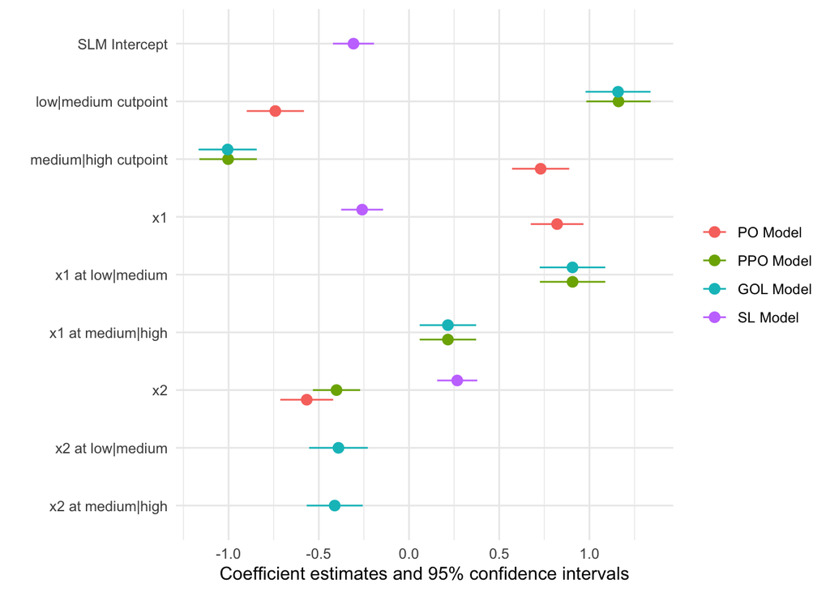

```r
# make plot comparing coefficients across models in modz

mapz <- c(
          "x2:2"           = "x2 at medium|high",
          "x2:1"           = "x2 at low|medium",
          "x2"             = "x2",
          "x1:2"           = "x1 at medium|high",
          "x1:1"           = "x1 at low|medium",
          "x1"             = "x1",
          "(Intercept):2"  = "medium|high cutpoint",
          "(Intercept):1"  = "low|medium cutpoint",
          "medium|high"    = "medium|high cutpoint",
          "low|medium"     = "low|medium cutpoint",
          "(Intercept)"    = "SLM Intercept"
          )

modelplot(modz,
          coef_map = mapz)
```

Keep in mind, too, that the SLM model doesn’t *really* appear appropriately in this plot (or in the table) because it doesn’t have the same structure as the other models. The SLM has a single coefficient for each predictor, but it also has the $\phi_j$ parameters that scale those coefficients at each threshold. So the SLM’s single coefficient for x1 is not directly comparable to the threshold-specific coefficients in the GOL or PPO, and the SLM’s single coefficient for x2 is not directly comparable to the single coefficients in the PO and PPO. The SLM is a different beast altogether, so it’s best to interpret its coefficients in the context of its own structure rather than trying to compare them directly to the other models.

So it seems like the SLM is a neat trick for diagnosing whether the ordering of the outcome categories is supported by the data. But it also seems really hard to interpret the findings when it comes to hypothesis testing.

That’s right. This is the main reason why I like to use this as a tool to help me understand my data and my model, but I don’t usually put it in the main text of a paper. It’s a bit too much for most readers to digest, and it can be hard to explain in a way that doesn’t leave people scratching their heads. But it’s a great tool to have in your back pocket when you’re trying to figure out what’s going on with your ordinal outcome. It can also be used to justify decisions you make about how to specify your model, which can be helpful when you have reviewers who are skeptical about your choice to relax the PO assumption.

#### When All Else Fails

If the proportional odds assumption is violated severely enough that even the PPO or SLM don’t fit well, multinomial logit (MNL) is a pretty good fallback option. An MNL model treats the outcome as completely unordered: no thresholds, no proportionality constraint, no scaling parameters. Instead, MNL is just a system of separate binary logits for each category (well, $j-1$ logits) versus a reference. This loses the ordinal structure of the outcome entirely, but it’s at least honest about what the model can and can’t tell you.

## The IIA Assumption

### What It Is

The multinomial logit model (MNL) is the standard model for nominal outcomes with three or more unordered categories. It rests on a structural assumption called the **independence of irrelevant alternatives** (IIA). It’s one of the most debated assumptions in the discrete choice literature, and understanding it well helps you make better decisions about when to use the MNL and when to consider alternatives.

The IIA assumption says that the odds of choosing alternative $j$ over alternative $k$ depend only on the characteristics of $j$ and $k$ — not on the characteristics of any other alternative in the choice set. Formally, for any two alternatives $j$ and $k$:

$$\frac{P(Y = j)}{P(Y = k)} = \frac{e^{\mathbf{x}^\top\boldsymbol{\beta}_j}}{e^{\mathbf{x}^\top\boldsymbol{\beta}_k}}$$

This ratio doesn’t involve the parameters for any other alternative. Adding a new alternative $m$ to the choice set doesn’t change the relative odds of $j$ versus $k$.

The most famous illustration of why this can be problematic is the **red bus/blue bus** problem, derived from Debreu (1960) (which was actually a book review, believe it or not!). Suppose a commuter currently chooses between driving a car and taking a red bus with equal probability (so the odds are 1:1). Now a blue bus service identical to the red bus in every respect is introduced. The IIA assumption implies that the odds of car versus red bus remain 1:1 after the blue bus is introduced. So the commuter ends up with probabilities 1/3 car, 1/3 red bus, 1/3 blue bus. But this is absurd: the commuter is presumably indifferent between the two buses and should end up at 1/2 car, 1/4 red bus, 1/4 blue bus.

Right. So it makes no sense to think of the choice between a blue bus and a red bus as equivalent to the choice between driving a car and riding the bus?

Exactly. Which means the MNL inflated the bus probability because it treated the two buses as independent alternatives rather than near-perfect substitutes.

### When Does IIA Matter?

The red bus/blue bus scenario is a deliberately extreme case. In most political science applications, the IIA assumption matters less dramatically, but it can still produce misleading results when your outcome categories are close substitutes for each other.

**Examples where IIA is likely violated:**

- Vote choice among candidates from the same ideological camp (left-wing voters choosing between two left parties)
- Coalition preferences among parties with overlapping platforms
- Policy preferences among options that share many features

**Examples where IIA is less likely to matter:**

- Choosing among outcome categories that are clearly distinct (e.g., different types of political regime)
- Outcomes where the full choice set is fixed and well-defined
- When the IIA-violating alternative is not present in your data

I see. So this seems like an assumption we should address with research design, not with statistical diagnostics.

Honestly, it’s probably both. Sometimes, it’s pretty obvious that the alternatives aren’t independent. In those cases, we know to be on the lookout for this kind of problem. But we *can* also test our models for evidence. The crucial question is not “does IIA technically hold?” but “does the violation of IIA materially affect the coefficients or predictions I care about?” A small IIA violation with negligible consequences is less worrying than a modest violation in a model whose policy implications depend on substitution patterns.

### Testing for IIA

Okay, so you just test whether IIA holds, and move on if it passes?

Not really. This is where things get uncomfortable. The two most widely used tests — the **Hausman-McFadden test** and the **Small-Hsiao test** — are both known to be unreliable. They can fail to detect genuine IIA violations (low power) and can reject IIA when it actually holds (poor size control), particularly in samples of the size typical in political science research. The Hausman-McFadden test can even produce negative test statistics, which is incoherent for a $\chi^2$ statistic.

Both tests work by comparing a full MNL (all alternatives) to a restricted MNL (with one alternative removed), under the logic that if IIA holds, the coefficients should be the same in both models. The problem is that the restricted model uses a non-random subsample of the data (observations that chose the removed alternative are dropped), which introduces selection bias into the comparison.

```r
# the Hausman-McFadden test is available via the mlogit package
# shown here for illustration — interpret cautiously

# reshape the data
data_full <- mlogit.data(mn.df, choice = "party", shape = "wide")
mn.df_filtered <- mn.df %>% filter(party != "D")
data_restrict <- mlogit.data(mn.df_filtered, choice = "party", shape = "wide")

# fit the full model
mn.mlogit <- mlogit(party ~ 1 | lr + ru, data = data_full, reflevel = "A")

# fit the restricted model
mn.restrict <- mlogit(party ~ 1 | lr + ru, data = data_restrict, reflevel = "A")

# Hausman-McFadden test
hmftest(mn.mlogit, mn.restrict)
```

```
##
##  Hausman-McFadden test
##
## data:  data_full
## chisq = -0.056, df = 9, p-value = 1
## alternative hypothesis: IIA is rejected
```

So, we fail the IIA? Or not?

In this case, we don’t fail the test, since we don’t reject the null hypothesis. But if we *had* failed the test, it’s not immediately clear what to do with that. Given the limitations of our tests, current practice is to treat IIA as a theoretical rather than an empirical question. Before running any test:

1. **Ask whether your outcome categories are plausible substitutes.** If they are, IIA is likely violated and an alternative model is warranted regardless of what a test says.
2. **Use the test as supporting evidence**, not as the primary justification for your model choice. If the test doesn’t reject IIA, that’s weak evidence in favor — not a green light to proceed without further thought.

### Stereotype Logit as a Diagnostic

This again?

Absolutely. It’s my favorite appendix model, so of course we’re going to use it as a diagnostic wherever we can. In this case, though, it really can be helpful. Even when you’re committed to MNL, it’s worth estimating the **stereotype logit model (SLM)** as a diagnostic. The SLM’s $\phi$ parameters test whether the outcome categories have an empirical ordering. If they’re monotonically increasing, that’s evidence of underlying ordinality. This might mean an ordered logit fits better than MNL. If they’re out of order or collapse categories together (consecutive $\phi$ values equal to each other), that’s evidence the categories don’t have a meaningful ordering and MNL is appropriate.

```r
# fit the SLM as a diagnostic for the nominal outcome
# constrained version: test whether outcome has ordinal structure
slm.nom <- VGAM::vglm(
  party ~ lr + ru,
  family = VGAM::sratio(parallel = FALSE ~ lr + ru),
  data   = mn.df
)

# extract the phi parameters — are they monotonically ordered?
# phi parameters are those named ":(Intercept)" in the coefficient vector
slm.coefs <- coef(slm.nom)
cat("SLM phi parameters:\n")
```

```
## SLM phi parameters:
```

```r
print(round(slm.coefs[grep("Intercept", names(slm.coefs))], 3))
```

```
## (Intercept):1 (Intercept):2 (Intercept):3
##        -1.492        -1.107         0.756
```

If the $\phi$ estimates are not monotonically ordered, the SLM is suggesting that your categories don’t have a clear empirical ordering — supporting the use of MNL.

These are supposed to be bounded by zero and one, right? So we fail?

### Alternatives to MNL When IIA Is Violated

When IIA is a genuine concern, you have several alternatives. All of them are more complex than MNL and require additional data or stronger assumptions. We won’t go through them all now, but you’ll want to explore these options is your model is truly suffering from IIA violation:

**Nested logit:** Groups alternatives into nests, with IIA holding within nests but not across them. A commuter who takes transit chooses first among transit options (bus, subway), then among driving options. The nesting structure must be specified by the researcher and is a strong theoretical assumption in itself. The `nestedLogit` package is one helpful tool for this solution.

**Mixed logit (random parameters logit):** Allows coefficients to vary across individuals, which naturally relaxes IIA. Computationally intensive and requires individual-level data on choice occasions. You can use tools in the `mlogit` package for this.

**Conditional logit with alternative-specific variables:** When your data include attributes of the alternatives themselves (not just characteristics of the chooser), the conditional logit model handles substitution patterns more flexibly than MNL. You can also accomplish this using tools in the `mlogit` package.

In practice, most political science applications of nominal DVs use MNL because the alternatives above require data structures that aren’t common in observational survey research. The honest approach is to:

1. make the case on theoretical grounds that your outcome categories are not close substitutes;
2. report the IIA tests as supplementary evidence while noting their limitations; and
3. discuss what IIA violation would imply for your substantive conclusions.

## Summary

```r
summ.tbl <- data.frame(
  Issue = c(
    "PO assumption holds?",
    "PO violated for some predictors",
    "PO violated for most/all predictors",
    "Category ordering questionable",
    "IIA — theoretical check",
    "IIA — formal test",
    "IIA violated"
  ),
  How_to_check = c(
    "Brant test (`brant::brant()`); LR test (`ordinal::nominal_test()`); threshold coefficient plot",
    "Which predictors? Variable-specific rows in Brant and nominal_test output",
    "Omnibus Brant or LR test significant; all predictors diverge across thresholds",
    "SLM phi parameters: are they monotonically ordered?",
    "Are outcome categories plausible substitutes? Theory first",
    "Hausman-McFadden or Small-Hsiao test — use cautiously; known reliability problems",
    "Which categories substitute for each other? Nesting structure plausible?"
  ),
  Response = c(
    "Proceed with PO model",
    "Partial proportional odds (`VGAM::vglm()` with `parallel = FALSE ~ violating_var`)",
    "Generalized ordered logit (`parallel = FALSE` globally) or SLM",
    "Re-examine category ordering; SLM; consider MNL if ordering is wrong",
    "If categories are close substitutes, plan for an alternative regardless of test result",
    "Treat as supplementary evidence only; never as the sole justification",
    "Nested logit; mixed logit; conditional logit; or acknowledge limitation and proceed with MNL"
  )
)

kable(
  summ.tbl,
  format = "html"
) %>%
  kable_styling(full_width = FALSE) %>%
  column_spec(
    1,
    width = "10em",
    bold = TRUE
  ) %>%
  column_spec(
    2,
    width = "20em",
    extra_css = "white-space: normal;"
  ) %>%
  column_spec(
    3,
    width = "20em",
    extra_css = "white-space: normal;"
  )
```

| Issue | How_to_check | Response |
| --- | --- | --- |
| PO assumption holds? | Brant test (`brant::brant()`); LR test (`ordinal::nominal_test()`); threshold coefficient plot | Proceed with PO model |
| PO violated for some predictors | Which predictors? Variable-specific rows in Brant and nominal_test output | Partial proportional odds (`VGAM::vglm()` with `parallel = FALSE ~ violating_var`) |
| PO violated for most/all predictors | Omnibus Brant or LR test significant; all predictors diverge across thresholds | Generalized ordered logit (`parallel = FALSE` globally) or SLM |
| Category ordering questionable | SLM phi parameters: are they monotonically ordered? | Re-examine category ordering; SLM; consider MNL if ordering is wrong |
| IIA — theoretical check | Are outcome categories plausible substitutes? Theory first | If categories are close substitutes, plan for an alternative regardless of test result |
| IIA — formal test | Hausman-McFadden or Small-Hsiao test — use cautiously; known reliability problems | Treat as supplementary evidence only; never as the sole justification |
| IIA violated | Which categories substitute for each other? Nesting structure plausible? | Nested logit; mixed logit; conditional logit; or acknowledge limitation and proceed with MNL |

## References

Debreu, Gerard. 1960. “[Review of Individual Choice Behavior: A Theoretical Analysis](https://www.jstor.org/stable/1813477).” *The American Economic Review* 50 (1): 186–88.

Long, J. S., and Jeremy Freese. 2014. *Regression Models for Categorical Dependent Variables Using Stata*. Vol. 3. Stata Press.

Patty, John W., and Elizabeth Maggie Penn. 2019. “A Defense of Arrow’s Independence of Irrelevant Alternatives.” *Public Choice* 179 (1): 145–64. https://doi.org/10.1007/s11127-018-0604-7.